# Homework 2

Instructions: For this homework you will create a Rmd document, an HTML document, and a PDF document and upload all three to wolfware.

The purpose of this homework is to get practice using R Markdown.

To Do - Write a Rmd file that recreates an HTML document with the above table of contents, title, etc. as well as the output below these instructions (no need to include the instructions). Use the same Rmd file to output a PDF file as well. **The PDF won’t have the tab functionality of the HTML document so don’t worry about that.**)

A few notes to help you out:

- I don’t care if the image is *exactly* the same size but do use a code chunk to render it. The image is sometimes corrupted if you open it in browser and then save it (or something like that). Be sure to download it as is.
- The web site link is https://lemire.me/blog/2017/11/10/should-computer-scientists-keep-the-lena-picture/
- You will need to load a number of packages including `knitr` (but notice we don’t see any output about that)
- Recall the `kable` function for creating nice tables in R Markdown output
- You will need to look up [tabsets and table of contents options](https://bookdown.org/yihui/rmarkdown/html-document.html)
- If you don’t have the package `ggplot2`, you’ll need to run the line `install.packages("ggplot2")` in your **console** prior to knitting the document (this code only needs to be done once)
- The last line about the minimum sepal length should have the number produced using inline R code.

End of instructions!

# Lena

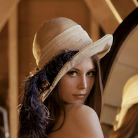

## Info

### Image information

This is a *famous image* used in **image processing**. Her name is Lena. For more details, check [this website](https://lemire.me/blog/2017/11/10/should-computer-scientists-keep-the-lena-picture/).

### References

The wikipedia article about Lena also references the following:

- Carole Hersee
- Lorem ipsum
  - filler text
  - useful for templates
- Shirley cards
- Suzanne
- Utah teapot
- China Girl

# Iris

## Averages

The `iris` data set includes information about iris flowers. Here are the means for the *Sepal Length* and *Sepal Width* variables using the `mean` and `round` functions:

| avgLength | avgWidth |
| --- | --- |
| 5.84 | 3.06 |

The code given here will produce plots of `Sepal.Length` vs `Sepal.Width` for the three **Species**. Note: this uses the `ggplot2` package - part of the `tidyverse`.

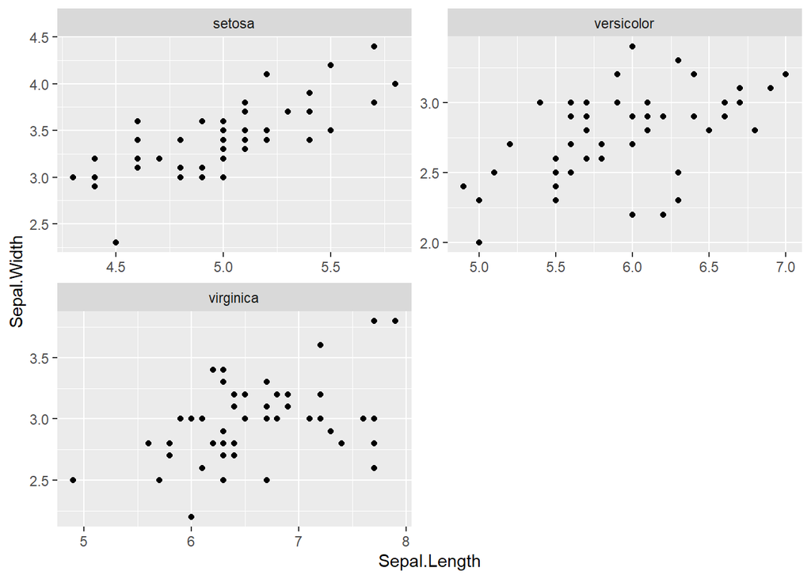

```r
library(ggplot2)
ggplot(iris, aes(x = Sepal.Length, y = Sepal.Width)) +
  geom_point() +
  facet_wrap(~ Species, ncol = 2, scales="free")
```

The smallest *Sepal Length* overall is 4.3.